# Self-Driving Car Engineer Nanodegree

## Project: Build a Traffic Sign Recognition Classifier

In this notebook, a template is provided for you to implement your functionality in stages, which is required to successfully complete this project. If additional code is required that cannot be included in the notebook, be sure that the Python code is successfully imported and included in your submission if necessary.

In addition to implementing code, there is a writeup to complete. The writeup should be completed in a separate file, which can be either a markdown file or a pdf document. There is a [write up template](https://github.com/udacity/CarND-Traffic-Sign-Classifier-Project/blob/master/writeup_template.md) that can be used to guide the writing process. Completing the code template and writeup template will cover all of the [rubric points](https://review.udacity.com/#!/rubrics/481/view) for this project.

The [rubric](https://review.udacity.com/#!/rubrics/481/view) contains "Stand Out Suggestions" for enhancing the project beyond the minimum requirements. The stand out suggestions are optional. If you decide to pursue the "stand out suggestions", you can include the code in this Ipython notebook and also discuss the results in the writeup file.

> **Note:** Code and Markdown cells can be executed using the **Shift + Enter** keyboard shortcut. In addition, Markdown cells can be edited by typically double-clicking the cell to enter edit mode.

## Step 0: Load The Data

```python
# Load pickled data
import os
import pickle

# TODO: Fill this in based on where you saved the training and testing data

dir_name = 'traffic-signs-data'

training_file = dir_name + os.sep + 'train.p'
validation_file = dir_name + os.sep + 'valid.p'
testing_file = dir_name + os.sep + 'test.p'

with open(training_file, mode='rb') as f:
    train = pickle.load(f)
with open(validation_file, mode='rb') as f:
    valid = pickle.load(f)
with open(testing_file, mode='rb') as f:
    test = pickle.load(f)

X_train, y_train = train['features'], train['labels']
X_valid, y_valid = valid['features'], valid['labels']
X_test, y_test = test['features'], test['labels']
```

## Step 1: Dataset Summary & Exploration

The pickled data is a dictionary with 4 key/value pairs:

- `'features'` is a 4D array containing raw pixel data of the traffic sign images, (num examples, width, height, channels).
- `'labels'` is a 1D array containing the label/class id of the traffic sign. The file `signnames.csv` contains id -> name mappings for each id.
- `'sizes'` is a list containing tuples, (width, height) representing the original width and height the image.
- `'coords'` is a list containing tuples, (x1, y1, x2, y2) representing coordinates of a bounding box around the sign in the image. **THESE COORDINATES ASSUME THE ORIGINAL IMAGE. THE PICKLED DATA CONTAINS RESIZED VERSIONS (32 by 32) OF THESE IMAGES**

Complete the basic data summary below. Use python, numpy and/or pandas methods to calculate the data summary rather than hard coding the results. For example, the [pandas shape method](http://pandas.pydata.org/pandas-docs/stable/generated/pandas.DataFrame.shape.html) might be useful for calculating some of the summary results.

### Provide a Basic Summary of the Data Set Using Python, Numpy and/or Pandas

```python
### Replace each question mark with the appropriate value.
### Use python, pandas or numpy methods rather than hard coding the results

import csv

all_labels = []
with open('signnames.csv', 'r') as f:
    read_csv = csv.reader(f, delimiter=',')
    for row in read_csv:
        all_labels += [row[1]]
    all_labels.remove('SignName')

# TODO: Number of training examples
n_train = len(X_train)

# TODO: Number of validation examples
n_validation = len(X_valid)

# TODO: Number of testing examples.
n_test = len(X_test)

# TODO: What's the shape of an traffic sign image?
image_shape = (X_train[0].shape)

# TODO: How many unique classes/labels there are in the dataset.
n_classes = len(all_labels)

print("Number of training examples =", n_train)
print("Number of testing examples =", n_test)
print("Image data shape =", image_shape)
print("Number of classes =", n_classes)
```

```
Number of training examples = 34799
Number of testing examples = 12630
Image data shape = (32, 32, 3)
Number of classes = 43
```

### Include an exploratory visualization of the dataset

Visualize the German Traffic Signs Dataset using the pickled file(s). This is open ended, suggestions include: plotting traffic sign images, plotting the count of each sign, etc.

The [Matplotlib](http://matplotlib.org/) [examples](http://matplotlib.org/examples/index.html) and [gallery](http://matplotlib.org/gallery.html) pages are a great resource for doing visualizations in Python.

**NOTE:** It's recommended you start with something simple first. If you wish to do more, come back to it after you've completed the rest of the sections. It can be interesting to look at the distribution of classes in the training, validation and test set. Is the distribution the same? Are there more examples of some classes than others?

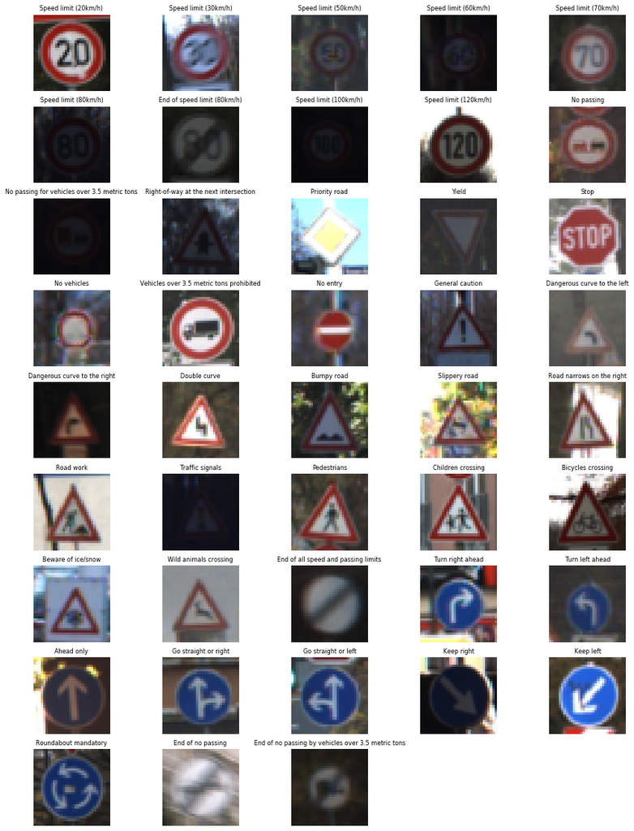

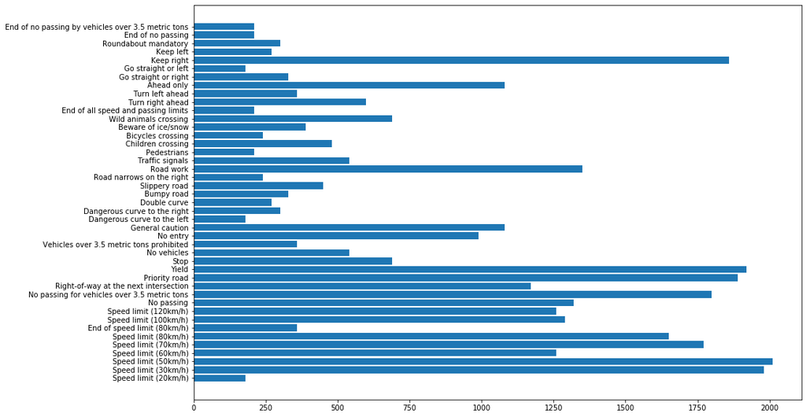

```python
### Data exploration visualization code goes here

import matplotlib.pyplot as plt
import random
import numpy as np
# Visualizations will be shown in the notebook.
%matplotlib inline

### Plot images with it label
plt.figure(figsize=(15,20))
for i in range(0, n_classes):
    plt.subplot(9, 5, i+1)
    plt.subplots_adjust(wspace=0.2)
    x_selected = X_train[y_train == i]
    random_selected_index = random.randint(0, x_selected.shape[0])
    plt.imshow(x_selected[random_selected_index, :, :, :])
    plt.title(all_labels[i], fontsize=8)
    plt.axis('off')
plt.show()

### Plot number of images per label
import numpy as np

plt.figure(figsize=(15, 10))
hist, bins = np.histogram(y_train, bins=n_classes)
left = (bins[:-1] + bins[1:]) / 2
plt.barh(left, hist, align='center')
plt.yticks(left, all_labels)
plt.show()
```

## Step 2: Design and Test a Model Architecture

Design and implement a deep learning model that learns to recognize traffic signs. Train and test your model on the [German Traffic Sign Dataset](http://benchmark.ini.rub.de/?section=gtsrb&subsection=dataset).

The LeNet-5 implementation shown in the classroom at the end of the CNN lesson is a solid starting point. You'll have to change the number of classes and possibly the preprocessing, but aside from that it's plug and play!

With the LeNet-5 solution from the lecture, you should expect a validation set accuracy of about 0.89. To meet specifications, the validation set accuracy will need to be at least 0.93. It is possible to get an even higher accuracy, but 0.93 is the minimum for a successful project submission.

There are various aspects to consider when thinking about this problem:

- Neural network architecture (is the network over or underfitting?)
- Play around preprocessing techniques (normalization, rgb to grayscale, etc)
- Number of examples per label (some have more than others).
- Generate fake data.

Here is an example of a [published baseline model on this problem](http://yann.lecun.com/exdb/publis/pdf/sermanet-ijcnn-11.pdf). It's not required to be familiar with the approach used in the paper but, it's good practice to try to read papers like these.

### Pre-process the Data Set (normalization, grayscale, etc.)

Minimally, the image data should be normalized so that the data has mean zero and equal variance. For image data, `(pixel - 128)/ 128` is a quick way to approximately normalize the data and can be used in this project.

Other pre-processing steps are optional. You can try different techniques to see if it improves performance.

Use the code cell (or multiple code cells, if necessary) to implement the first step of your project.

[figure not shown]

```
Number of preprocessed training examples = 69598
```

```python
### Preprocess the data here. It is required to normalize the data. Other preprocessing steps could include
### converting to grayscale, etc.

import tensorflow as tf

# random saturation change
r_saturation_X = tf.image.random_saturation(X_train, lower=0.4, upper=0.7)
processed_X_train = np.concatenate((X_train, r_saturation_X), axis=0)
processed_y_train = np.concatenate((y_train, y_train), axis=0)

### Plot images with it label
plt.figure(figsize=(15,20))
for i in range(0, n_classes):
    plt.subplot(9, 5, i+1)
    plt.subplots_adjust(wspace=0.2)
    x_selected = processed_X_train[processed_y_train == i]
    random_selected_index = random.randint(x_selected.shape[0]/2, x_selected.shape[0]-1)
    plt.imshow(x_selected[random_selected_index, :, :, :])
    plt.title(all_labels[i], fontsize=8)
    plt.axis('off')
plt.show()

# normalization(standardization): avoid out of memory
std_processed_X_train = tf.image.per_image_standardization(tf.convert_to_tensor(processed_X_train, np.float32))
std_X_valid = tf.image.per_image_standardization(tf.convert_to_tensor(X_valid, np.float32))
std_X_test = tf.image.per_image_standardization(tf.convert_to_tensor(X_test, np.float32))

print("Number of preprocessed training examples =", len(processed_X_train))
```

### Model Architecture

```python
### Define your architecture here.

nn_model = tf.keras.models.Sequential()

# Layer : Convolutional. Input:32x32x3, Output:30x30x6. (filters=6, kernel_size=(3, 3))
nn_model.add(tf.keras.layers.Conv2D(6, (3, 3), padding='VALID', activation='relu', input_shape=(32, 32, 3)))

# Layer : Dropout.
nn_model.add(tf.keras.layers.Dropout(0.2))

# Layer : Pooling. Input:30x30x6, Output:28x28x6. (pool_size=(3, 3), strides=(1, 1))
nn_model.add(tf.keras.layers.MaxPooling2D((3, 3), (1, 1), padding='VALID'))

# Layer : Convolutional. Input:28x28x6, Output:24x24x11. (filters=14, kernel_size=(5, 5))
nn_model.add(tf.keras.layers.Conv2D(14, (5, 5), padding='VALID', activation='relu'))

# Layer : Dropout.
nn_model.add(tf.keras.layers.Dropout(0.3))

# Layer : Pooling. Input:24x24x11, Output:12x12x11. (pool_size=(2, 2), strides=(2, 2))
nn_model.add(tf.keras.layers.MaxPooling2D((2, 2), (2, 2), padding='VALID'))

# Layer : Convolutional. Input:12x12x11. Output:6x6x18. (filters=22, kernel_size=(7, 7))
nn_model.add(tf.keras.layers.Conv2D(22, (7, 7), padding='VALID', activation='relu'))

# Layer : Dropout
nn_model.add(tf.keras.layers.Dropout(0.5))

# Layer : Pooling. Input:6x6x18, Output:5x5x22. (pool_size(2, 2), strides=(1, 1))
nn_model.add(tf.keras.layers.MaxPooling2D((2, 2), (1, 1), padding='VALID'))

# Layer : Fully Connected. Input:5x5x22, Output:550.
nn_model.add(tf.keras.layers.Flatten())

# Layer : Fully Connected. Input:550, Output:150.
nn_model.add(tf.keras.layers.Dense(150, kernel_regularizer=tf.keras.regularizers.l2(0.003), activation='relu'))

# Layer : Fully Connected. Input:150, Output:100.
nn_model.add(tf.keras.layers.Dense(100, kernel_regularizer=tf.keras.regularizers.l2(0.001), activation='relu'))

# Layer : Fully Connected. Input:100, Output:43.
nn_model.add(tf.keras.layers.Dense(43, activation='softmax'))

# show model summary
nn_model.summary()
```

```
Model: "sequential"
_________________________________________________________________
Layer (type)                 Output Shape              Param #
=================================================================
conv2d (Conv2D)              (None, 30, 30, 6)         168
_________________________________________________________________
dropout (Dropout)            (None, 30, 30, 6)         0
_________________________________________________________________
max_pooling2d (MaxPooling2D) (None, 28, 28, 6)         0
_________________________________________________________________
conv2d_1 (Conv2D)            (None, 24, 24, 14)        2114
_________________________________________________________________
dropout_1 (Dropout)          (None, 24, 24, 14)        0
_________________________________________________________________
max_pooling2d_1 (MaxPooling2 (None, 12, 12, 14)        0
_________________________________________________________________
conv2d_2 (Conv2D)            (None, 6, 6, 22)          15114
_________________________________________________________________
dropout_2 (Dropout)          (None, 6, 6, 22)          0
_________________________________________________________________
max_pooling2d_2 (MaxPooling2 (None, 5, 5, 22)          0
_________________________________________________________________
flatten (Flatten)            (None, 550)               0
_________________________________________________________________
dense (Dense)                (None, 150)               82650
_________________________________________________________________
dense_1 (Dense)              (None, 100)               15100
_________________________________________________________________
dense_2 (Dense)              (None, 43)                4343
=================================================================
Total params: 119,489
Trainable params: 119,489
Non-trainable params: 0
_________________________________________________________________
```

### Train, Validate and Test the Model

A validation set can be used to assess how well the model is performing. A low accuracy on the training and validation sets imply underfitting. A high accuracy on the training set but low accuracy on the validation set implies overfitting.

```python
### Train your model here.
### Calculate and report the accuracy on the training and validation set.
### Once a final model architecture is selected,
### the accuracy on the test set should be calculated and reported as well.

# compile the model
nn_model.compile(optimizer='rmsprop', loss='sparse_categorical_crossentropy', metrics=['accuracy'])

# train the model
history = nn_model.fit(std_processed_X_train, processed_y_train, epochs=25, batch_size=256,
                       validation_data=(std_X_valid, y_valid), verbose=2)
```

```
Train on 69598 samples, validate on 4410 samples
69598/69598 - 6s - loss: 1.4352 - accuracy: 0.7406 - val_loss: 0.8763 - val_accuracy: 0.9150
69598/69598 - 4s - loss: 0.5040 - accuracy: 0.9387 - val_loss: 0.6307 - val_accuracy: 0.9347
69598/69598 - 4s - loss: 0.3168 - accuracy: 0.9617 - val_loss: 0.4362 - val_accuracy: 0.9560
69598/69598 - 4s - loss: 0.2334 - accuracy: 0.9714 - val_loss: 0.3943 - val_accuracy: 0.9533
69598/69598 - 4s - loss: 0.1873 - accuracy: 0.9768 - val_loss: 0.2971 - val_accuracy: 0.9696
69598/69598 - 4s - loss: 0.1592 - accuracy: 0.9793 - val_loss: 0.2999 - val_accuracy: 0.9524
69598/69598 - 4s - loss: 0.1390 - accuracy: 0.9813 - val_loss: 0.2269 - val_accuracy: 0.9680
69598/69598 - 4s - loss: 0.1242 - accuracy: 0.9831 - val_loss: 0.2341 - val_accuracy: 0.9653
69598/69598 - 4s - loss: 0.1123 - accuracy: 0.9844 - val_loss: 0.2116 - val_accuracy: 0.9642
69598/69598 - 4s - loss: 0.1036 - accuracy: 0.9858 - val_loss: 0.2693 - val_accuracy: 0.9524
69598/69598 - 4s - loss: 0.0951 - accuracy: 0.9865 - val_loss: 0.2091 - val_accuracy: 0.9728
69598/69598 - 4s - loss: 0.0909 - accuracy: 0.9863 - val_loss: 0.1921 - val_accuracy: 0.9676
69598/69598 - 4s - loss: 0.0853 - accuracy: 0.9876 - val_loss: 0.1930 - val_accuracy: 0.9683
69598/69598 - 4s - loss: 0.0804 - accuracy: 0.9883 - val_loss: 0.1998 - val_accuracy: 0.9612
69598/69598 - 4s - loss: 0.0769 - accuracy: 0.9890 - val_loss: 0.1911 - val_accuracy: 0.9601
69598/69598 - 4s - loss: 0.0752 - accuracy: 0.9887 - val_loss: 0.1731 - val_accuracy: 0.9676
69598/69598 - 4s - loss: 0.0700 - accuracy: 0.9894 - val_loss: 0.1511 - val_accuracy: 0.9744
69598/69598 - 4s - loss: 0.0679 - accuracy: 0.9899 - val_loss: 0.1342 - val_accuracy: 0.9776
69598/69598 - 4s - loss: 0.0693 - accuracy: 0.9897 - val_loss: 0.1319 - val_accuracy: 0.9819
69598/69598 - 4s - loss: 0.0640 - accuracy: 0.9902 - val_loss: 0.1683 - val_accuracy: 0.9646
69598/69598 - 4s - loss: 0.0640 - accuracy: 0.9904 - val_loss: 0.1476 - val_accuracy: 0.9744
69598/69598 - 4s - loss: 0.0626 - accuracy: 0.9907 - val_loss: 0.1297 - val_accuracy: 0.9794
69598/69598 - 4s - loss: 0.0595 - accuracy: 0.9910 - val_loss: 0.1393 - val_accuracy: 0.9771
69598/69598 - 4s - loss: 0.0583 - accuracy: 0.9912 - val_loss: 0.1269 - val_accuracy: 0.9819
69598/69598 - 4s - loss: 0.0575 - accuracy: 0.9916 - val_loss: 0.1261 - val_accuracy: 0.9757
```

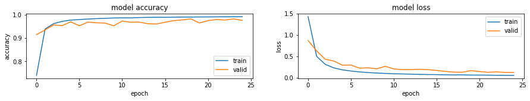

```python
# learning history result
plt.figure(figsize=(15, 2))
plt.subplot(1, 2, 1)
plt.plot(history.history['accuracy'])
plt.plot(history.history['val_accuracy'])
plt.title('model accuracy')
plt.ylabel('accuracy')
plt.xlabel('epoch')
plt.legend(['train', 'valid'], loc='lower right')

plt.subplot(1, 2, 2)
plt.plot(history.history['loss'])
plt.plot(history.history['val_loss'])
plt.title('model loss')
plt.ylabel('loss')
plt.xlabel('epoch')
plt.legend(['train', 'valid'], loc='upper right')
plt.show()
```

```python
# evaluate the model
test_loss, test_acc = nn_model.evaluate(std_X_test, y_test, verbose=0)
print('test_loss    : ' + str(test_loss))
print('test_accuracy: ' + str(test_acc))
```

```
test_loss    : 0.23132280325568674
test_accuracy: 0.9515439
```

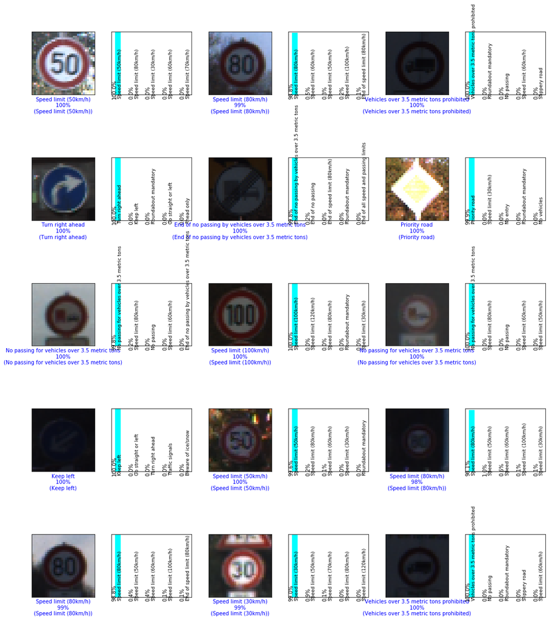

```python
### Summary of prediction for test set

## function for summary of prediction
def plot_image_with_label(img, predicted_label_idx, predicted_label, true_label_idx, true_label, prediction_prob):
    plt.grid(False)
    plt.xticks([])
    plt.yticks([])
    plt.imshow(img, cmap=plt.cm.binary)

    if predicted_label_idx == true_label_idx:
        color = 'blue'
    else:
        color = 'red'

    plt.xlabel("{}\n {:2.0f}% \n({})".format(predicted_label, prediction_prob*100, true_label), color=color)


def plot_top5_value_array(prediction_array, all_labels):

    prediction_top5_idx = (-prediction_array).argsort()[:5]
    prediction_top5_array = prediction_array[prediction_top5_idx]
    top5_label = [all_labels[i] for i in prediction_top5_idx]

    plt.grid(False)
    plt.xticks(range(5), top5_label, rotation=90, size=9, wrap=True, ha='left')
    plt.yticks([])
    thisplot = plt.bar(range(5), prediction_top5_array, color='#777777', width=0.3)
    for x in range(5):
        plt.text(x-0.35, -0.05, "{:2.1f}%".format(prediction_top5_array[x]*100), rotation=90)
    plt.ylim([0, 1])

    thisplot[0].set_color('cyan')


def prediction_analyze(input_images, test_images, test_label_id, num_rows, num_cols, random_choice=True):
    # load model prediction result for test set
    prediction = nn_model.predict(tf.convert_to_tensor(input_images, np.float32))

    # calculate number of output image
    num_images = num_rows * num_cols

    # plot random select result
    indexes = np.arange(len(test_label_id))
    if random_choice:
        indexes = np.random.choice(indexes, num_images, replace=False)
    plt.figure(figsize=(3*2*num_cols, 4*num_rows))
    plt.subplots_adjust(hspace=1.0, wspace=0.1)
    count = 0
    for i in indexes:
        img = test_images[i]
        prediction_array = prediction[i]
        prediction_prob = np.max(prediction_array)
        predicted_label_idx = np.argmax(prediction_array)
        predicted_label = all_labels[predicted_label_idx]
        true_label_idx = test_label_id[i]
        true_label = all_labels[true_label_idx]

        # plot random choiced image
        plt.subplot(num_rows, 2*num_cols, 2*count+1)
        plot_image_with_label(img, predicted_label_idx, predicted_label, true_label_idx, true_label, prediction_prob)

        # plot top5 value
        plt.subplot(num_rows, 2*num_cols, 2*count+2)
        plot_top5_value_array(prediction_array, all_labels)

        count += 1
    plt.show()


# analyze prediction result of test set
prediction_analyze(std_X_test, X_test, y_test, num_rows=5, num_cols=3)
```

## Step 3: Test a Model on New Images

To give yourself more insight into how your model is working, download at least five pictures of German traffic signs from the web and use your model to predict the traffic sign type.

You may find `signnames.csv` useful as it contains mappings from the class id (integer) to the actual sign name.

### Load and Output the Images

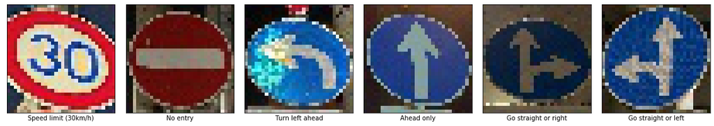

```python
### Load the images and plot them here.

from PIL import Image

data_path = 'traffic-signs-data' + os.sep + 'new' + os.sep

new_X_test = np.zeros((6, 32, 32, 3), dtype=int)
new_X_test[0] = np.array(Image.open(data_path + '1_Speed_limit_30.jpg'))
new_X_test[1] = np.array(Image.open(data_path + '17_No_entry.jpg'))
new_X_test[2] = np.array(Image.open(data_path + '34_Turn_left_ahead.jpg'))
new_X_test[3] = np.array(Image.open(data_path + '35_Ahead_only.jpg'))
new_X_test[4] = np.array(Image.open(data_path + '36_Go_straight_or_right.jpg'))
new_X_test[5] = np.array(Image.open(data_path + '37_Go_straight_or_left.jpg'))

new_y_test = np.array([1, 17, 34, 35, 36, 37])

plt.figure(figsize=(20, 10))
plt.subplots_adjust(hspace=1.0, wspace=0.1)
for i in range(6):
    plt.subplot(1, 6, i+1)
    plt.grid(False)
    plt.xticks([])
    plt.yticks([])
    plt.imshow(new_X_test[i], cmap=plt.cm.binary)
    plt.xlabel("{}".format(all_labels[new_y_test[i]]))
```

### Predict the Sign Type for Each Image

```python
### Run the predictions here and use the model to output the prediction for each image.
### Make sure to pre-process the images with the same pre-processing pipeline used earlier.
std_new_X_test = tf.image.per_image_standardization(tf.convert_to_tensor(new_X_test, np.float32))
new_prediction = nn_model.predict(tf.convert_to_tensor(std_new_X_test, np.float32))
```

### Analyze Performance

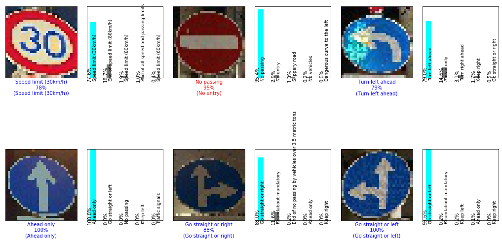

```python
### Calculate the accuracy for these 5 new images.
### For example, if the model predicted 1 out of 5 signs correctly, it's 20% accurate on these new images.
prediction_analyze(std_new_X_test, new_X_test, new_y_test, num_rows=2, num_cols=3, random_choice=False)
```

### Output Top 5 Softmax Probabilities For Each Image Found on the Web

For each of the new images, print out the model's softmax probabilities to show the **certainty** of the model's predictions (limit the output to the top 5 probabilities for each image). [`tf.nn.top_k`](https://www.tensorflow.org/versions/r0.12/api_docs/python/nn.html#top_k) could prove helpful here.

The example below demonstrates how tf.nn.top_k can be used to find the top k predictions for each image.

`tf.nn.top_k` will return the values and indices (class ids) of the top k predictions. So if k=3, for each sign, it'll return the 3 largest probabilities (out of a possible 43) and the correspoding class ids.

Take this numpy array as an example. The values in the array represent predictions. The array contains softmax probabilities for five candidate images with six possible classes. `tf.nn.top_k` is used to choose the three classes with the highest probability:

```
# (5, 6) array
a = np.array([[ 0.24879643,  0.07032244,  0.12641572,  0.34763842,  0.07893497,
         0.12789202],
       [ 0.28086119,  0.27569815,  0.08594638,  0.0178669 ,  0.18063401,
         0.15899337],
       [ 0.26076848,  0.23664738,  0.08020603,  0.07001922,  0.1134371 ,
         0.23892179],
       [ 0.11943333,  0.29198961,  0.02605103,  0.26234032,  0.1351348 ,
         0.16505091],
       [ 0.09561176,  0.34396535,  0.0643941 ,  0.16240774,  0.24206137,
         0.09155967]])
```

Running it through `sess.run(tf.nn.top_k(tf.constant(a), k=3))` produces:

```
TopKV2(values=array([[ 0.34763842,  0.24879643,  0.12789202],
       [ 0.28086119,  0.27569815,  0.18063401],
       [ 0.26076848,  0.23892179,  0.23664738],
       [ 0.29198961,  0.26234032,  0.16505091],
       [ 0.34396535,  0.24206137,  0.16240774]]), indices=array([[3, 0, 5],
       [0, 1, 4],
       [0, 5, 1],
       [1, 3, 5],
       [1, 4, 3]], dtype=int32))
```

Looking just at the first row we get `[ 0.34763842, 0.24879643, 0.12789202]`, you can confirm these are the 3 largest probabilities in `a`. You'll also notice `[3, 0, 5]` are the corresponding indices.

```python
### Print out the top five softmax probabilities for the predictions on the German traffic sign images found on the web.

# use later
incorrect_label_id = -1
incorrect_new_img_idx = -1

# print
for i in range(6):

    prediction_top5_idx = (-new_prediction[i]).argsort()[:5]
    prediction_top5_array = new_prediction[i][prediction_top5_idx]
    top5_label = [all_labels[i] for i in prediction_top5_idx]

    # save incorrect_label_id
    if all_labels[new_y_test[i]] != top5_label[0]:
        incorrect_prediction_label = top5_label[0]
        incorrect_label = all_labels[new_y_test[i]]
        incorrect_label_id = prediction_top5_idx[0]
        incorrect_new_img_idx = i

    print("correct label: {}".format(all_labels[new_y_test[i]]))
    for j in range(5):
        print("\t{}: {:3.4f}  {}".format(j+1, prediction_top5_array[j], top5_label[j]))
```

```
correct label: Speed limit (30km/h)
	1: 0.7759  Speed limit (30km/h)
	2: 0.1867  End of speed limit (80km/h)
	3: 0.0186  Speed limit (80km/h)
	4: 0.0102  End of all speed and passing limits
	5: 0.0040  Speed limit (60km/h)
correct label: No entry
	1: 0.9541  No passing
	2: 0.0291  No entry
	3: 0.0134  Slippery road
	4: 0.0019  No vehicles
	5: 0.0004  Dangerous curve to the left
correct label: Turn left ahead
	1: 0.7898  Turn left ahead
	2: 0.1458  Ahead only
	3: 0.0307  Turn right ahead
	4: 0.0166  Keep right
	5: 0.0054  Go straight or right
correct label: Ahead only
	1: 0.9995  Ahead only
	2: 0.0002  Go straight or left
	3: 0.0001  No passing
	4: 0.0001  Keep left
	5: 0.0000  Traffic signals
correct label: Go straight or right
	1: 0.8800  Go straight or right
	2: 0.1163  Roundabout mandatory
	3: 0.0025  End of no passing by vehicles over 3.5 metric tons
	4: 0.0003  Ahead only
	5: 0.0003  Keep right
correct label: Go straight or left
	1: 0.9955  Go straight or left
	2: 0.0017  Roundabout mandatory
	3: 0.0017  Keep left
	4: 0.0005  Ahead only
	5: 0.0002  Keep right
```

### Project Writeup

Once you have completed the code implementation, document your results in a project writeup using this [template](https://github.com/udacity/CarND-Traffic-Sign-Classifier-Project/blob/master/writeup_template.md) as a guide. The writeup can be in a markdown or pdf file.

## Step 4 (Optional): Visualize the Neural Network's State with Test Images

This Section is not required to complete but acts as an additional excersise for understaning the output of a neural network's weights. While neural networks can be a great learning device they are often referred to as a black box. We can understand what the weights of a neural network look like better by plotting their feature maps. After successfully training your neural network you can see what it's feature maps look like by plotting the output of the network's weight layers in response to a test stimuli image. From these plotted feature maps, it's possible to see what characteristics of an image the network finds interesting. For a sign, maybe the inner network feature maps react with high activation to the sign's boundary outline or to the contrast in the sign's painted symbol.

Provided for you below is the function code that allows you to get the visualization output of any tensorflow weight layer you want. The inputs to the function should be a stimuli image, one used during training or a new one you provided, and then the tensorflow variable name that represents the layer's state during the training process, for instance if you wanted to see what the LeNet lab's feature maps looked like for it's second convolutional layer you could enter conv2 as the tf_activation variable.

For an example of what feature map outputs look like, check out NVIDIA's results in their paper [End-to-End Deep Learning for Self-Driving Cars](https://devblogs.nvidia.com/parallelforall/deep-learning-self-driving-cars/) in the section Visualization of internal CNN State. NVIDIA was able to show that their network's inner weights had high activations to road boundary lines by comparing feature maps from an image with a clear path to one without. Try experimenting with a similar test to show that your trained network's weights are looking for interesting features, whether it's looking at differences in feature maps from images with or without a sign, or even what feature maps look like in a trained network vs a completely untrained one on the same sign image.

[figure not shown]

Your output should look something like this (above)

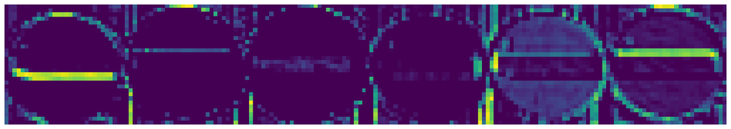

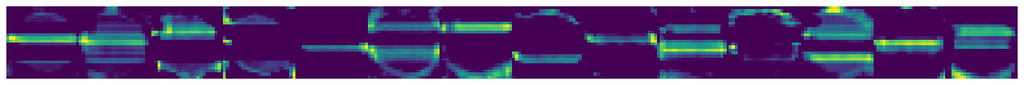

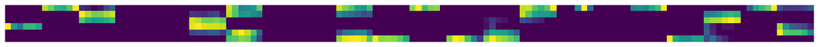

```python
### Visualize your network's feature maps here.

img_idx = incorrect_new_img_idx
if img_idx == -1:
    img_idx = 0

def layer_output(layer, img_idx):
    fig = plt.figure(figsize=(20, 10))
    plt.subplots_adjust(wspace=0)
    for i in range(layer.shape[3]):
        ax = fig.add_subplot(1, layer.shape[3], i+1)
        ax.matshow(layer[img_idx, :, :, i])
        ax.set_axis_off()
    plt.show()

# Layer : conv2d
mid_layer1_model = tf.keras.models.Model(inputs=nn_model.input, outputs=nn_model.get_layer('conv2d').output)
mid_layer1_output = mid_layer1_model.predict(std_new_X_test)

# Layer : conv2d_1
mid_layer2_model = tf.keras.models.Model(inputs=nn_model.input, outputs=nn_model.get_layer('conv2d_1').output)
mid_layer2_output = mid_layer2_model.predict(std_new_X_test)

# Layer : conv2d_2
mid_layer3_model = tf.keras.models.Model(inputs=nn_model.input, outputs=nn_model.get_layer('conv2d_2').output)
mid_layer3_output = mid_layer3_model.predict(std_new_X_test)

layer_output(mid_layer1_output, img_idx)
layer_output(mid_layer2_output, img_idx)
layer_output(mid_layer3_output, img_idx)
```

[output not shown]

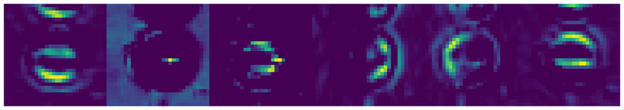

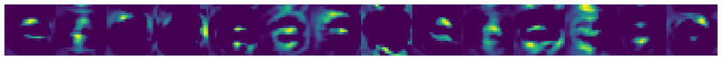

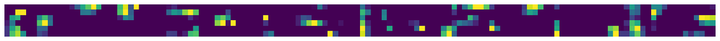

```python
incorrect_img_idx = np.where(y_test == incorrect_label_id)

if incorrect_label_id == -1:
    print("prediction is all correct in new test images")
else:
    print("correct label is {} but prediction is {}".format(incorrect_label, incorrect_prediction_label))
    print("plot {} images feature maps here".format(incorrect_prediction_label))
    # Layer : conv2d
    mid_layer1_model = tf.keras.models.Model(inputs=nn_model.input, outputs=nn_model.get_layer('conv2d').output)
    mid_layer1_output = mid_layer1_model.predict(std_X_test)

    # Layer : conv2d_1
    mid_layer2_model = tf.keras.models.Model(inputs=nn_model.input, outputs=nn_model.get_layer('conv2d_1').output)
    mid_layer2_output = mid_layer2_model.predict(std_X_test)

    # Layer : conv2d_2
    mid_layer3_model = tf.keras.models.Model(inputs=nn_model.input, outputs=nn_model.get_layer('conv2d_2').output)
    mid_layer3_output = mid_layer3_model.predict(std_X_test)

    layer_output(mid_layer1_output, incorrect_img_idx[0][0])
    layer_output(mid_layer2_output, incorrect_img_idx[0][0])
    layer_output(mid_layer3_output, incorrect_img_idx[0][0])
```